# Readme2

Bonnell, Faltesek, Gates, Lohberger

9/1/2021

```r
knitr::opts_chunk$set(echo = TRUE)
library(ImagePlotX)
```

## Why Image Plotting?

In 2011, the Software Studies Initiative released a macro known as Image Plot for ImageJ. When combined with a system for measuring the properties of images, the macro allowed users to compose an Image Plot, where the images that they were analyzing would appear themselves as the points of a scatterplot. This is an extremely useful way to analyze visual data as it allows everyone to see the both a meta representation of information about the optical qualities of the images while experiencing them visually. The original documentation focused on patterns of change through an artists collection, for example, how did the works of Mondrain or Van Goh change through the years?

Underlying much of the rise of Cultural Analytics is the tension between close and distant reading which is often overplayed. The close reading of a particular image will always be an important project, what distant reading methods can provide are: ways of visualizing entire collections, tests for normative claims to clustering or trends, generative documents for encouraging new hypothesis formation. In this sense, the plots produced as image plots appear very much like marginalia in reading or notes taken during field work.

We designed this package to interface with the tidyverse more generally, all of our measurements are collected in dataframes with one case per row, our tables can easily be joined to make a very wide dataframe. The end plotting logic of this package is geom_image for ggplot2. If you are functional with dplyr and ggplot2, this package should provide you with a comprehensive set of image plotting tools.

### Importing

Our basic importer function takes the name of your folder in quotes and yields a dataframe with each local and global path. This basic loader does not do anything to the images or even read them, it is a simplifier that helps you know where your files actually are.

```r
A<-"/Users/faltesed/Documents/One/mittens"
load_images(A)
```

```
##  [1] "/Users/faltesed/Documents/One/mittens/58d7005687456f7f1d8b46b6_da39a3ee5e6b4b0d3255bfef95601890afd80709.jpg"
##  [2] "/Users/faltesed/Documents/One/mittens/58d8a39887456f4c718b4574_da39a3ee5e6b4b0d3255bfef95601890afd80709.jpg"
##  [3] "/Users/faltesed/Documents/One/mittens/58d9558f87456f65058b45fd_da39a3ee5e6b4b0d3255bfef95601890afd80709.jpg"
##  [4] "/Users/faltesed/Documents/One/mittens/58d9558f87456f65058b45fd_da39a3ee5e6b4b0d3255bfef95601890afd80709.png"
##  [5] "/Users/faltesed/Documents/One/mittens/591c084587456fd56a8b45c5_da39a3ee5e6b4b0d3255bfef95601890afd80709.jpg"
##  [6] "/Users/faltesed/Documents/One/mittens/591c08fe87456fdb068b45bb_da39a3ee5e6b4b0d3255bfef95601890afd80709.jpg"
##  [7] "/Users/faltesed/Documents/One/mittens/591c093a87456fdb068b45bd_da39a3ee5e6b4b0d3255bfef95601890afd80709.jpg"
##  [8] "/Users/faltesed/Documents/One/mittens/591ec9c087456fb3208b4568_da39a3ee5e6b4b0d3255bfef95601890afd80709.jpg"
##  [9] "/Users/faltesed/Documents/One/mittens/5922b64c87456f02158b4592_da39a3ee5e6b4b0d3255bfef95601890afd80709.jpg"
## [10] "/Users/faltesed/Documents/One/mittens/5922b70987456f79178b456f_da39a3ee5e6b4b0d3255bfef95601890afd80709.jpg"
## [11] "/Users/faltesed/Documents/One/mittens/5922b77c87456f56158b458c_da39a3ee5e6b4b0d3255bfef95601890afd80709.jpg"
## [12] "/Users/faltesed/Documents/One/mittens/5922b7f187456f02158b45a2_da39a3ee5e6b4b0d3255bfef95601890afd80709.jpg"
## [13] "/Users/faltesed/Documents/One/mittens/592b0de887456fd7158b456b_da39a3ee5e6b4b0d3255bfef95601890afd80709.jpg"
## [14] "/Users/faltesed/Documents/One/mittens/592c4fcc87456fb1368b458c_da39a3ee5e6b4b0d3255bfef95601890afd80709.jpg"
## [15] "/Users/faltesed/Documents/One/mittens/593db3f487456fa7348b45e3_da39a3ee5e6b4b0d3255bfef95601890afd80709.jpg"
## [16] "/Users/faltesed/Documents/One/mittens/5956c9ba87456f2f2e8b457f_da39a3ee5e6b4b0d3255bfef95601890afd80709.jpg"
## [17] "/Users/faltesed/Documents/One/mittens/5aa0eca087456ff31d8b4569_da39a3ee5e6b4b0d3255bfef95601890afd80709.jpg"
## [18] "/Users/faltesed/Documents/One/mittens/5aa0ef1e87456f33228b4571_da39a3ee5e6b4b0d3255bfef95601890afd80709.jpg"
## [19] "/Users/faltesed/Documents/One/mittens/5c6247045cfdce37b6a8559e_da39a3ee5e6b4b0d3255bfef95601890afd80709.jpg"
```

```r
images
```

```
##                                                                                                     local_path
## 1  /Users/faltesed/Documents/One/mittens/58d7005687456f7f1d8b46b6_da39a3ee5e6b4b0d3255bfef95601890afd80709.jpg
## 2  /Users/faltesed/Documents/One/mittens/58d8a39887456f4c718b4574_da39a3ee5e6b4b0d3255bfef95601890afd80709.jpg
## 3  /Users/faltesed/Documents/One/mittens/58d9558f87456f65058b45fd_da39a3ee5e6b4b0d3255bfef95601890afd80709.jpg
## 4  /Users/faltesed/Documents/One/mittens/58d9558f87456f65058b45fd_da39a3ee5e6b4b0d3255bfef95601890afd80709.png
## 5  /Users/faltesed/Documents/One/mittens/591c084587456fd56a8b45c5_da39a3ee5e6b4b0d3255bfef95601890afd80709.jpg
## 6  /Users/faltesed/Documents/One/mittens/591c08fe87456fdb068b45bb_da39a3ee5e6b4b0d3255bfef95601890afd80709.jpg
## 7  /Users/faltesed/Documents/One/mittens/591c093a87456fdb068b45bd_da39a3ee5e6b4b0d3255bfef95601890afd80709.jpg
## 8  /Users/faltesed/Documents/One/mittens/591ec9c087456fb3208b4568_da39a3ee5e6b4b0d3255bfef95601890afd80709.jpg
## 9  /Users/faltesed/Documents/One/mittens/5922b64c87456f02158b4592_da39a3ee5e6b4b0d3255bfef95601890afd80709.jpg
## 10 /Users/faltesed/Documents/One/mittens/5922b70987456f79178b456f_da39a3ee5e6b4b0d3255bfef95601890afd80709.jpg
## 11 /Users/faltesed/Documents/One/mittens/5922b77c87456f56158b458c_da39a3ee5e6b4b0d3255bfef95601890afd80709.jpg
## 12 /Users/faltesed/Documents/One/mittens/5922b7f187456f02158b45a2_da39a3ee5e6b4b0d3255bfef95601890afd80709.jpg
## 13 /Users/faltesed/Documents/One/mittens/592b0de887456fd7158b456b_da39a3ee5e6b4b0d3255bfef95601890afd80709.jpg
## 14 /Users/faltesed/Documents/One/mittens/592c4fcc87456fb1368b458c_da39a3ee5e6b4b0d3255bfef95601890afd80709.jpg
```

[output cut: 25 more lines]

This is always your starting point, which is helpful as it yields an entry in your global environment. It is often helpful to have your files in a single format, which in our case would be PNG. Our function convert_and_import will take the result of your load_images and will convert all of your images to PNG it will put them in a single folder named “converted” in the home directory of your R project. Each image will be assigned a new filename which is a random combination of numbers and letters, which is associated with the original name for that file.

WARNING: if you run convert and import multiple times, your converted directory will get larger and larger. In accordance with tidy principals our functions are non-destructive. Furthermore, we can imagine use cases where you might chose to convert and land in a single directory for further analysis. If you want to have a clean convert_and_import, delete the directory between function runs.

```r
convert_and_import(images)
```

```
## Warning in dir.create("converted"): 'converted' already exists
```

### Basic Measurement

A second useful measurement method is fluency analysis, which employs the methods from the image fluency package, fielding a dataframe with contrast, self_similarity, symmetry, and complexity. This is a slower function that many others, but can produce really useful results for your analysis.

```r
measure_images(converted_images)
```

```
## [1] "OCR results may be misleading if images include no text"
```

#### Your First Plot

```r
#for your join
library(dplyr)
```

[figure not shown]

```r
library(ggplot2)

#combine the data side by side
mypictures<-bind_cols(converted_images, measured_images)

#the plotting code
imageplot_output("mypictures", "a", "info.filesize", .5)
```

## Colors

Basic Colors mean_red Deviation_red Mean_green Deviation_green Mean_blue Deviation_blue

### Color Theory

To understand what these measure we need to take a detour into some color theory. In many primary schools the primary colors are taught as red, blue, and yellow. For subtractive color and rudimentary paints this then leads to a series of mixing choices and lovely paintings. More advanced versions of this, such as in offset printing, use cyan, magenta, and yellow, often with a layer of black to save money and produce higher contrast line effects, thus CMYK. There are colors where this is not quite as consistent and sharp as we may like which leads to more specific inks, pantones and the like. With light, we are adding colors to produce white.

Hue, saturation, and value provide another useful set of measurements for color. We can imagine use cases where you might prefer to use these factors rather than thinking about which raw RGB specifications. For example, it might be helpful to look for trends in saturation or comparing saturation and the use of a certain color, like red. While it would be possible to ask users to calculate their own transformations between RGB and HSV, we simply provide all in the dataframe for speed and convenience.

#### Color Plotting

```r
color_analysis(converted_images)
```

[output not shown]

```r
head(colors_results)
```

```
##    mean_red deviation_red mean_blue deviation_blue mean_green deviation_green
## 1 117.11502      82.31252  88.79870       66.00366  102.35877        58.17986
## 2 161.93493      64.66204  76.91463       51.31085  103.76824        56.02132
## 3  65.21476      90.48715  43.34958       74.11275   63.92489        90.36359
## 4  95.22748      80.30425  84.37147       64.31143   87.05828        67.79372
## 5  88.03879      50.50799  52.42174       39.39110   69.99647        49.37203
## 6  82.46434      86.86910  86.22966       88.84886   96.72034        95.62029
##     mean_hue deviation_hue mean_saturation deviation_saturation mean_value
## 1 0.40725905    0.32287026       0.5595321            0.3361771  0.5620809
## 2 0.06069669    0.05900861       0.5343190            0.1687705  0.6351353
## 3 0.32903292    0.28677013       0.7819609            0.3345989  0.3357170
## 4 0.43619702    0.29610081       0.5429274            0.3131320  0.4527997
## 5 0.27011363    0.33012500       0.4579164            0.2571795  0.3486168
## 6 0.35249228    0.26457506       0.6322478            0.3256856  0.4274369
##   deviation_saturation.1 luminance lum_contrast   hue_region
## 1              0.3361771 102.75750     68.83201       Orange
## 2              0.1687705 114.20593     57.33140       Orange
## 3              0.3345989  57.49641     84.98783       Orange
## 4              0.3131320  88.88574     70.80313       Orange
## 5              0.2571795  70.15233     46.42371       Orange
## 6              0.3256856  88.47145     90.44608 Spring green
```

[figure not shown]

```r
mypictures<-bind_cols(mypictures, colors_results)

imageplot_output("mypictures", "mean_red", "mean_blue", .5)
```

While there was a symmetry method used in the basic section, we have written a few additional functions that work with proportion and balance. Our methods in this section are concerned with finding lines.

### Symmetry_anaylsis.

Ten items to report: Horizontal symmetry SD of the top region, SD of the bottom

Vertical symmetry Sd of the left region, sd of the right region

Central diagonal symmetry along an integral x~y Central region Corner region

### Thirds_analysis

This is our approach for reading images for the use of a standard set of composition trends known as the rule of thirds. Compositions generally position key figures on a tic-tac-toe like grid. This function segments each image into four thirds regions which are then compared for canny edges so that we can compre. NEgative scores mean that there is more activity not on the third, positive scores mean there is more there than the other third. If all scores are very low, it is likely that the image does not conform to the rule of thirds.

### Edges_analysis

This is by far our most largest measurement.

Includes a region by region breakdown of the canny edges detected in each region and the relative standard deviation of the edges in that region. Each region also has a skewness measure and a kurtosis measure, which speak to how much in any given region the distribution leans and how peaky it is.

The use cases for this particular model would include looking at staks for particular regions where there is a higher density of activity or looking for defocused or empty areas. An approach looking for images that are blue with low edge values in regions 1-4 would be a “sky” detector. If faces were known to be in the images and thirds were established, the scores for R8 and R 12 could be used to look for lead room. There are many ways that you can imagine using this approach to compare particular areas across a set of images, we hope this particular result, while voluminous, is flexible.

Each represents one-sixteenth of the image numbered in rows from the top left corner, which is R1. The extreme bottom right is R16.

It is straight forward to write new functions that could approximate symmetry or focus detection Note: it is not uncommon for this function to throw NaN when there are regions of the graphic with no edges. This is a drawback of our method.

### Advanced Analysis Methods

So far you are familiar with our basic plotting function. This is intended to help folks who are unfamilar create meaningful plots.

Within the function there are really three distinct things happening: A. a function is “passing alpha” to adjust the transparency of your images. B. a ggplot2 object is using the standard grammar of graphics approach to build a plot C. the library ggimage is being used to append the images with modified alpha, which requires a specific assignment of file names

[figure not shown]

```r
library(ggplot2)

#sub-routine A is passing alpha
transparent <- function(img){magick::image_fx(img, expression= ".1*a", channel = "alpha")}

#B is the basic GG plot
ggplot(mypictures, aes(a, info.filesize))+
  #and C is the geom
  ggimage::geom_image(image=mypictures$local_path,image_fun=transparent) + coord_polar()
```

### Styles

Because we are using the gg paradigm for producing output graphics, all of your strategies for using ggplot2 can be used here as well. Because we are using a particular geom, we can’t play with many of the options on the front side of the cheatsheet. The back right hand side, is going to be where the fun begins.

[figure not shown]

```r
#old stuff
transparent <- function(img){magick::image_fx(img, expression= ".1*a", channel = "alpha")}

ggplot(mypictures, aes(a, info.filesize))+
  ggimage::geom_image(image=mypictures$local_path,image_fun=transparent) +
  #newstuff
  #let's make this polar with a linedrawn background and a big title
  coord_polar()+theme_linedraw()+labs(title = "Mittens Are Warm.")
```

While aeshtetics aren’t perfect here, you can start to see how for things like a symmetry plot or other times when we are looking for outliers a polar plot could be really powerful.

#### Facets

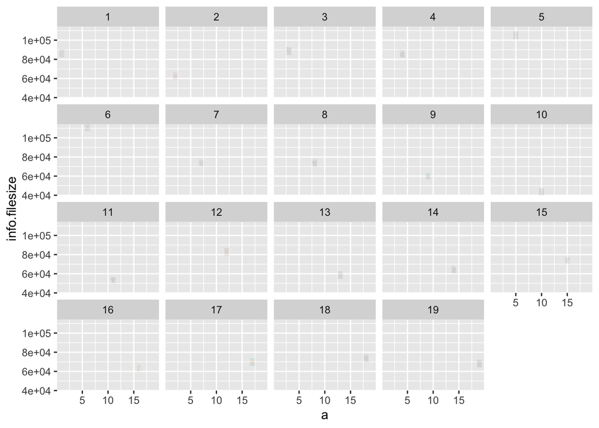

```r
#old stuff
transparent <- function(img){magick::image_fx(img, expression= ".1*a", channel = "alpha")}

ggplot(mypictures, aes(a, info.filesize))+
  ggimage::geom_image(image=mypictures$local_path,image_fun=transparent) +
  #newstuff
  #no styling, but definitely faceting
  facet_wrap(~a)
```